# SASC: Paired multiome, Part 1

Dr. Kevin Z. Lin (UW Biostatistics)

June 17, 2025

# Loading packages

```r
library(Seurat) # from https://satijalab.org/seurat/articles/install_v5
library(Signac) # from https://stuartlab.org/signac/articles/install
library(ggplot2)
library(patchwork)
library(RSQLite)
library(EnsDb.Mmusculus.v79) # from https://bioconductor.org/packages/release/data/annotation/html/EnsDb.Mmusculus.v79.html
library(BSgenome.Mmusculus.UCSC.mm10) # from https://www.bioconductor.org/packages/release/data/annotation/html/BSgenome.Mmusculus.UCSC.mm10.html
library(JASPAR2020)
library(TFBSTools)
library(ggseqlogo)
library(devtools)
library(biovizBase) #BiocManager::install("biovizBase")
library(motifmatchr) #BiocManager::install("motifmatchr")
```

# Creating the scATAC-seq data

This is tutorial is based on [https://stuartlab.org/signac/articles/mouse_brain_vignette](https://urldefense.com/v3/__https://stuartlab.org/signac/articles/mouse_brain_vignette__;!!K-Hz7m0Vt54!l8z1cgLimWUehjP-UQXj91E35KMe10j2zUI4OsZMQE77jhZVMfT9o31RJUgPZ5_ownyYzyxepSIl$). Download the files from:

- http://cf.10xgenomics.com/samples/cell-atac/1.1.0/atac_v1_adult_brain_fresh_5k/atac_v1_adult_brain_fresh_5k_filtered_peak_bc_matrix.h5
- http://cf.10xgenomics.com/samples/cell-atac/1.1.0/atac_v1_adult_brain_fresh_5k/atac_v1_adult_brain_fresh_5k_fragments.tsv.gz
- http://cf.10xgenomics.com/samples/cell-atac/1.1.0/atac_v1_adult_brain_fresh_5k/atac_v1_adult_brain_fresh_5k_fragments.tsv.gz.tbi
- You’ll also need the `atac_v1_adult_brain_fresh_5k_singlecell_kzl-updated.csv` file created for this tutorial.

The following code is to create the Seurat object for snATAC-seq data. Notably, you need to use the `Signac::CreateChromatinAssay()` function, where you need to not only tell the function the count matrix `counts`, but also where the `.tsv.gz` file is. This is because `Signac` has functions that functions that require knowing specifically if there’s a cut at any particular base pair (in the reference genome), not simply just how many cuts happen at a peak region. (The matrix `counts`, is simply a tally of how many cuts happen within a region, which is not high-resolution enough for some of the `Signac` functions.)

**Note about wording**: We will be using the words “chromatin region” and “peak” interchangeably.

```r
setwd("/Users/kevinlin/Library/CloudStorage/Dropbox/Collaboration-and-People/sumie-katie/tutorial/sasc_2025/")

counts <- Seurat::Read10X_h5("atac_v1_adult_brain_fresh_5k_filtered_peak_bc_matrix.h5")
metadata <- read.csv(
  file = "atac_v1_adult_brain_fresh_5k_singlecell_kzl-updated.csv",
  header = TRUE,
  row.names = 1
)

seurat_atac <- Signac::CreateChromatinAssay(
  counts = counts,
  sep = c(":", "-"),
  genome = "mm10",
  fragments = 'atac_v1_adult_brain_fresh_5k_fragments.tsv.gz',
  min.cells = 1
)

# If you see this error: "Error: vector memory exhausted (limit reached?)"
# You can try `Sys.setenv(R_MAX_VSIZE = "100Gb")` beforehand

seurat_obj <- Seurat::CreateSeuratObject(
  counts = seurat_atac,
  assay = 'ATAC',
  meta.data = metadata
)
seurat_atac
```

```
#> Computing hash
#> ChromatinAssay data with 157203 features for 5337 cells
#> Variable features: 0
#> Genome: mm10
#> Annotation present: FALSE
#> Motifs present: FALSE
#> Fragment files: 1
```

We can take a look at the first 5 cells and first 5 peaks in `seurat_obj`. We see that the peak names (which come from CellRanger, prior to doing any analysis in R) denote the start and end of the peak region, and the count refers to how many cuts were detected (after CellRanger’s own preprocessing) in that region.

```r
SeuratObject::LayerData(seurat_obj,
                        layer = "counts",
                        assay = "ATAC")[1:5,1:5]
```

```
#> 5 x 5 sparse Matrix of class "dgCMatrix"
#>                      AAACGAAAGTAATCAG-1 AAACGAACACGCTGTG-1 AAACGAATCCTGGGAC-1
#> chr1-3094708-3095552                  .                  .                  .
#> chr1-3119414-3121782                  2                  .                  .
#> chr1-3204809-3205178                  .                  .                  .
#> chr1-3217330-3217359                  .                  .                  .
#> chr1-3228123-3228463                  2                  .                  .
#>                      AAACGAATCGGGAAAC-1 AAACTCGAGAAAGCAG-1
#> chr1-3094708-3095552                  .                  .
#> chr1-3119414-3121782                  .                  .
#> chr1-3204809-3205178                  .                  .
#> chr1-3217330-3217359                  .                  .
#> chr1-3228123-3228463                  .                  .
```

We now need to do some cleanup on `seurat_obj`. This primarily is to set up the backend so any future bioinformatics analysis knows what the reference genome is, the specific naming convention being used, etc.

```r
# extract gene annotations from EnsDb
annotations <- Signac::GetGRangesFromEnsDb(ensdb = EnsDb.Mmusculus.v79)

# change to UCSC style since the data was mapped to hg19
GenomeInfoDb::seqlevels(annotations) <- paste0('chr', GenomeInfoDb::seqlevels(annotations))
GenomeInfoDb::genome(annotations) <- "mm10"

# add the gene information to the object
Signac::Annotation(seurat_obj) <- annotations
```

[output not shown]

```r
seurat_obj
```

```
#> An object of class Seurat
#> 157203 features across 5337 samples within 1 assay
#> Active assay: ATAC (157203 features, 0 variable features)
#>  2 layers present: counts, data
```

```r
summary(seurat_obj@meta.data)
```

```
#>          orig.ident    nCount_ATAC     nFeature_ATAC       total
#>  SeuratProject:3512   Min.   :   125   Min.   :   64   Min.   :  7195
#>  NA's         :1825   1st Qu.:  1772   1st Qu.:  916   1st Qu.: 31616
#>                       Median : 17096   Median : 7160   Median : 54697
#>                       Mean   : 22386   Mean   : 8812   Mean   : 63216
#>                       3rd Qu.: 36524   3rd Qu.:14351   3rd Qu.: 85281
#>                       Max.   :144369   Max.   :43785   Max.   :301971
#>                                                        NA's   :1825
#>    duplicate         chimeric         unmapped         lowmapq
#>  Min.   :  2324   Min.   :  12.0   Min.   :  63.0   Min.   :  178
#>  1st Qu.: 16744   1st Qu.: 201.0   1st Qu.: 400.8   1st Qu.: 1152
#>  Median : 28630   Median : 353.0   Median : 700.0   Median : 2152
#>  Mean   : 33332   Mean   : 414.9   Mean   : 828.5   Mean   : 2645
#>  3rd Qu.: 44430   3rd Qu.: 560.0   3rd Qu.:1139.2   3rd Qu.: 3645
#>  Max.   :168033   Max.   :1942.0   Max.   :5014.0   Max.   :14338
#>  NA's   :1825     NA's   :1825     NA's   :1825     NA's   :1825
#>  mitochondrial     passed_filters         cell_id     is__cell_barcode
#>  Min.   :   0.00   Min.   :  3692   _cell_0   :   1   Min.   :1
#>  1st Qu.:   5.00   1st Qu.: 12722   _cell_1   :   1   1st Qu.:1
#>  Median :  32.00   Median : 22376   _cell_10  :   1   Median :1
#>  Mean   :  69.81   Mean   : 25926   _cell_1001:   1   Mean   :1
#>  3rd Qu.:  87.00   3rd Qu.: 35147   _cell_1002:   1   3rd Qu.:1
#>  Max.   :2061.00   Max.   :132085   (Other)   :3507   Max.   :1
#>  NA's   :1825      NA's   :1825     NA's      :1825   NA's   :1825
#>  TSS_fragments   DNase_sensitive_region_fragments enhancer_region_fragments
#>  Min.   : 1185   Min.   : 2362                    Min.   :  915
#>  1st Qu.: 4956   1st Qu.: 8436                    1st Qu.: 3806
#>  Median : 7852   Median :13805                    Median : 6720
#>  Mean   : 8476   Mean   :15295                    Mean   : 7637
#>  3rd Qu.:11215   3rd Qu.:20440                    3rd Qu.:10433
#>  Max.   :36136   Max.   :71824                    Max.   :38517
#>  NA's   :1825    NA's   :1825                     NA's   :1825
#>  promoter_region_fragments on_target_fragments blacklist_region_fragments
#>  Min.   :  980             Min.   : 2865       Min.   :  0.00
#>  1st Qu.: 4490             1st Qu.:10084       1st Qu.: 16.00
#>  Median : 7011             Median :16796       Median : 39.00
#>  Mean   : 7451             Mean   :18817       Mean   : 61.43
#>  3rd Qu.: 9785             3rd Qu.:25252       3rd Qu.: 85.00
#>  Max.   :30549             Max.   :89107       Max.   :572.00
#>  NA's   :1825              NA's   :1825        NA's   :1825
```

[output cut: 9 more lines]

```
#>  Min.   :0.3341    Min.   :0.0100        NS < 4:3512      Min.   : 2.587
#>  1st Qu.:0.6198    1st Qu.:0.2500        NA's  :1825      1st Qu.: 4.414
#>  Median :0.7501    Median :0.4800                         Median : 5.069
#>  Mean   :0.7830    Mean   :0.4792                         Mean   : 5.555
#>  3rd Qu.:0.9036    3rd Qu.:0.7000                         3rd Qu.: 6.276
#>  Max.   :3.0157    Max.   :0.9800                         Max.   :13.824
#>  NA's   :1825      NA's   :1825                           NA's   :1825
#>  TSS.percentile   high.tss    pct_reads_in_peaks blacklist_ratio
#>  Min.   :0.0400   High:3506   Min.   :40.25      Min.   :0.0000
#>  1st Qu.:0.3100   Low :   6   1st Qu.:65.21      1st Qu.:0.0013
#>  Median :0.5100   NA's:1825   Median :70.67      Median :0.0026
#>  Mean   :0.5184               Mean   :69.86      Mean   :0.0037
#>  3rd Qu.:0.7300               3rd Qu.:75.53      3rd Qu.:0.0048
#>  Max.   :0.9900               Max.   :86.31      Max.   :0.0247
#>  NA's   :1825                 NA's   :1825       NA's   :1825
```

# Compute quality-control statistics

We now want to compute some quality-control statistics. One common one is `Signac::NucleosomeSignal()`. As you can see in [https://stuartlab.org/signac/reference/nucleosomesignal](https://urldefense.com/v3/__https://stuartlab.org/signac/reference/nucleosomesignal__;!!K-Hz7m0Vt54!l8z1cgLimWUehjP-UQXj91E35KMe10j2zUI4OsZMQE77jhZVMfT9o31RJUgPZ5_ownyYzz2AIZ4O$) and [https://stuartlab.org/signac/articles/pbmc_vignette#computing-qc-metrics](https://urldefense.com/v3/__https://stuartlab.org/signac/articles/pbmc_vignette*computing-qc-metrics__;Iw!!K-Hz7m0Vt54!l8z1cgLimWUehjP-UQXj91E35KMe10j2zUI4OsZMQE77jhZVMfT9o31RJUgPZ5_ownyYz4JQfpkS$), this diagnostic uses the following logic: “The histogram of DNA fragment sizes (determined from the paired-end sequencing reads) should exhibit a strong nucleosome banding pattern corresponding to the length of DNA wrapped around a single nucleosome”

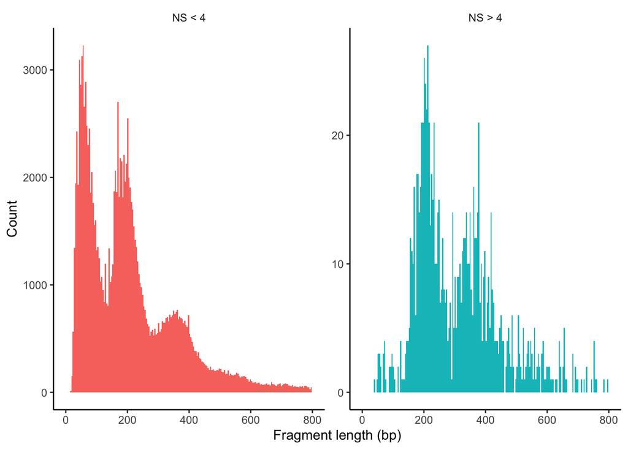

```r
seurat_obj <- Signac::NucleosomeSignal(seurat_obj)
seurat_obj$nucleosome_group <- ifelse(seurat_obj$nucleosome_signal > 4, 'NS > 4', 'NS < 4')
Signac::FragmentHistogram(seurat_obj,
                          group.by = 'nucleosome_group',
                          region = 'chr1-1-10000000')
```

Another is `Signac::TSSEnrichment()`. As you can see in [https://stuartlab.org/signac/reference/tssenrichment](https://urldefense.com/v3/__https://stuartlab.org/signac/reference/tssenrichment__;!!K-Hz7m0Vt54!l8z1cgLimWUehjP-UQXj91E35KMe10j2zUI4OsZMQE77jhZVMfT9o31RJUgPZ5_ownyYz0HqPxPX$) and [https://stuartlab.org/signac/articles/pbmc_vignette#computing-qc-metrics](https://urldefense.com/v3/__https://stuartlab.org/signac/articles/pbmc_vignette*computing-qc-metrics__;Iw!!K-Hz7m0Vt54!l8z1cgLimWUehjP-UQXj91E35KMe10j2zUI4OsZMQE77jhZVMfT9o31RJUgPZ5_ownyYz4JQfpkS$), this diagnostic uses the following logic: “The ENCODE project has defined an ATAC-seq targeting score based on the ratio of fragments centered at the TSS to fragments in TSS-flanking regions. Poor ATAC-seq experiments typically will have a low TSS enrichment score.”

```r
# the following line takes a couple minutes to run if you set "fast=FALSE"
## However, you'll need to set `fast=FALSE` in order to run the Signac::TSSPlot line
seurat_obj <- Signac::TSSEnrichment(seurat_obj,
                                    fast = FALSE)
```

```
#> Extracting TSS positions
#> Finding + strand cut sites
#> Finding - strand cut sites
#> Computing mean insertion frequency in flanking regions
#> Normalizing TSS score
```

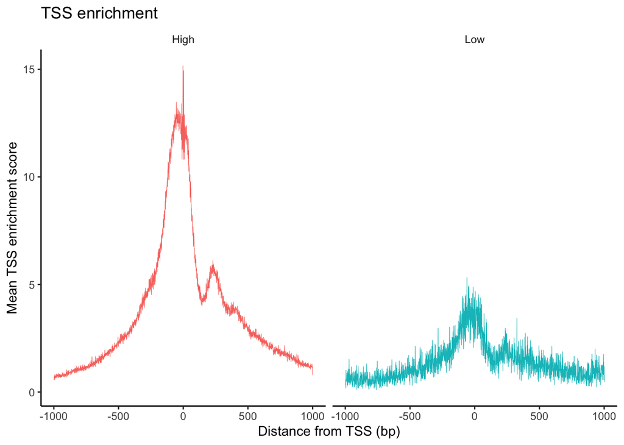

```r
# from https://stuartlab.org/signac/1.13.0/articles/pbmc_vignette
seurat_obj$high.tss <- ifelse(seurat_obj$TSS.enrichment > 3, 'High', 'Low')
Signac::TSSPlot(seurat_obj, group.by = 'high.tss') + Seurat::NoLegend()
```

Finally, there are “known” regions that consistently show abnormally high, unstructured, or irreproducible signal in sequencing assays. These are the “blacklist” regions, we can also filter out cells that have too high counts in these regions. See more in [https://stuartlab.org/signac/articles/pbmc_vignette#computing-qc-metrics](https://urldefense.com/v3/__https://stuartlab.org/signac/articles/pbmc_vignette*computing-qc-metrics__;Iw!!K-Hz7m0Vt54!l8z1cgLimWUehjP-UQXj91E35KMe10j2zUI4OsZMQE77jhZVMfT9o31RJUgPZ5_ownyYz4JQfpkS$).

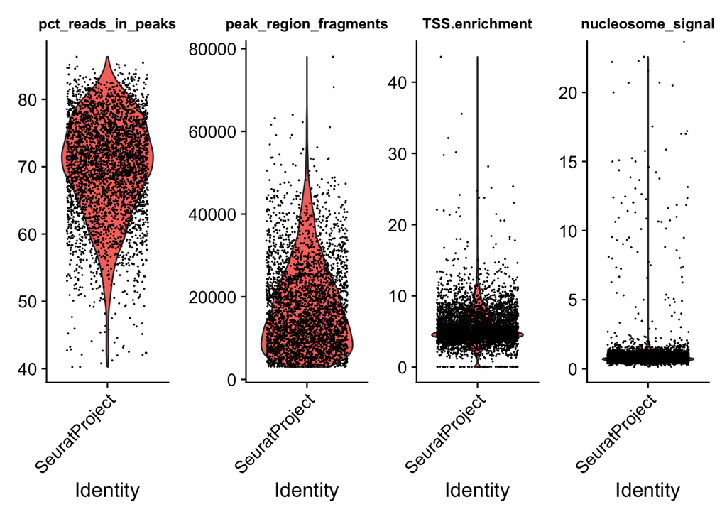

```r
seurat_obj$pct_reads_in_peaks <- seurat_obj$peak_region_fragments / seurat_obj$passed_filters * 100
seurat_obj$blacklist_ratio <- seurat_obj$blacklist_region_fragments / seurat_obj$peak_region_fragments

all_plots <- Seurat::VlnPlot(seurat_obj,
                             features = c('pct_reads_in_peaks',
                                          'peak_region_fragments',
                                          'TSS.enrichment',
                                          'nucleosome_signal'),
                             ncol = 4)
for(i in 1:length(all_plots)){
  all_plots[[i]] <- all_plots[[i]] + ggplot2::theme(plot.title = element_text(size=10))
}

all_plots
```

```r
summary(seurat_obj@meta.data)
```

```
#>          orig.ident    nCount_ATAC     nFeature_ATAC       total
#>  SeuratProject:3512   Min.   :   125   Min.   :   64   Min.   :  7195
#>  NA's         :1825   1st Qu.:  1772   1st Qu.:  916   1st Qu.: 31616
#>                       Median : 17096   Median : 7160   Median : 54697
#>                       Mean   : 22386   Mean   : 8812   Mean   : 63216
#>                       3rd Qu.: 36524   3rd Qu.:14351   3rd Qu.: 85281
#>                       Max.   :144369   Max.   :43785   Max.   :301971
#>                                                        NA's   :1825
#>    duplicate         chimeric         unmapped         lowmapq
#>  Min.   :  2324   Min.   :  12.0   Min.   :  63.0   Min.   :  178
#>  1st Qu.: 16744   1st Qu.: 201.0   1st Qu.: 400.8   1st Qu.: 1152
#>  Median : 28630   Median : 353.0   Median : 700.0   Median : 2152
#>  Mean   : 33332   Mean   : 414.9   Mean   : 828.5   Mean   : 2645
#>  3rd Qu.: 44430   3rd Qu.: 560.0   3rd Qu.:1139.2   3rd Qu.: 3645
#>  Max.   :168033   Max.   :1942.0   Max.   :5014.0   Max.   :14338
#>  NA's   :1825     NA's   :1825     NA's   :1825     NA's   :1825
#>  mitochondrial     passed_filters         cell_id     is__cell_barcode
#>  Min.   :   0.00   Min.   :  3692   _cell_0   :   1   Min.   :1
#>  1st Qu.:   5.00   1st Qu.: 12722   _cell_1   :   1   1st Qu.:1
#>  Median :  32.00   Median : 22376   _cell_10  :   1   Median :1
#>  Mean   :  69.81   Mean   : 25926   _cell_1001:   1   Mean   :1
#>  3rd Qu.:  87.00   3rd Qu.: 35147   _cell_1002:   1   3rd Qu.:1
#>  Max.   :2061.00   Max.   :132085   (Other)   :3507   Max.   :1
#>  NA's   :1825      NA's   :1825     NA's      :1825   NA's   :1825
#>  TSS_fragments   DNase_sensitive_region_fragments enhancer_region_fragments
#>  Min.   : 1185   Min.   : 2362                    Min.   :  915
#>  1st Qu.: 4956   1st Qu.: 8436                    1st Qu.: 3806
#>  Median : 7852   Median :13805                    Median : 6720
#>  Mean   : 8476   Mean   :15295                    Mean   : 7637
#>  3rd Qu.:11215   3rd Qu.:20440                    3rd Qu.:10433
#>  Max.   :36136   Max.   :71824                    Max.   :38517
#>  NA's   :1825    NA's   :1825                     NA's   :1825
#>  promoter_region_fragments on_target_fragments blacklist_region_fragments
#>  Min.   :  980             Min.   : 2865       Min.   :  0.00
#>  1st Qu.: 4490             1st Qu.:10084       1st Qu.: 16.00
#>  Median : 7011             Median :16796       Median : 39.00
#>  Mean   : 7451             Mean   :18817       Mean   : 61.43
#>  3rd Qu.: 9785             3rd Qu.:25252       3rd Qu.: 85.00
#>  Max.   :30549             Max.   :89107       Max.   :572.00
#>  NA's   :1825              NA's   :1825        NA's   :1825
```

[output cut: 9 more lines]

```
#>  Min.   :0.1333    Min.   :0.0000        Length:5337        Min.   : 0.01468
#>  1st Qu.:0.6204    1st Qu.:0.2500        Class :character   1st Qu.: 4.22249
#>  Median :0.7619    Median :0.5000        Mode  :character   Median : 5.03201
#>  Mean   :   Inf    Mean   :0.5002                           Mean   : 5.59982
#>  3rd Qu.:0.9472    3rd Qu.:0.7500                           3rd Qu.: 6.52046
#>  Max.   :   Inf    Max.   :1.0000                           Max.   :43.55644
#>
#>  TSS.percentile     high.tss         pct_reads_in_peaks blacklist_ratio
#>  Min.   :0.0000   Length:5337        Min.   :40.25      Min.   :0.0000
#>  1st Qu.:0.2500   Class :character   1st Qu.:65.21      1st Qu.:0.0013
#>  Median :0.5000   Mode  :character   Median :70.67      Median :0.0026
#>  Mean   :0.5001                      Mean   :69.86      Mean   :0.0037
#>  3rd Qu.:0.7500                      3rd Qu.:75.53      3rd Qu.:0.0048
#>  Max.   :1.0000                      Max.   :86.31      Max.   :0.0247
#>                                      NA's   :1825       NA's   :1825
```

# Quality-control subsetting the cells

We’re going to subset a lot more aggressively (i.e., throw out more cells than needed) for the sake of making this tutorial faster.

```r
seurat_obj <- subset(seurat_obj,
                     subset = peak_region_fragments > 15000 &
                       peak_region_fragments < 80000 &
                       pct_reads_in_peaks > 70 &
                       blacklist_ratio < 0.025 &
                       nucleosome_signal < 4 &
                       TSS.enrichment > 2
)

seurat_obj
```

```
#> An object of class Seurat
#> 157203 features across 779 samples within 1 assay
#> Active assay: ATAC (157203 features, 0 variable features)
#>  2 layers present: counts, data
```

```r
head(seurat_obj@meta.data)
```

```
#>                       orig.ident nCount_ATAC nFeature_ATAC  total duplicate
#> AAACGAATCCTGGGAC-1 SeuratProject       36442         14771  61593     32424
#> AAACTCGAGAAAGCAG-1 SeuratProject       52576         20373  96762     52465
#> AAACTCGTCCAACGCG-1 SeuratProject       48475         19282  87177     48158
#> AAACTCGTCCATCATT-1 SeuratProject       74635         26209 150222     88579
#> AAACTCGTCTGGGCGT-1 SeuratProject       43751         16182  98110     64431
#> AAACTGCGTAGAACGC-1 SeuratProject       37483         15777  59200     28330
#>                    chimeric unmapped lowmapq mitochondrial passed_filters
#> AAACGAATCCTGGGAC-1      466      672    2226            37          25768
#> AAACTCGAGAAAGCAG-1      510     1163    3699            36          38889
#> AAACTCGTCCAACGCG-1      623      988    2872            50          34486
#> AAACTCGTCCATCATT-1     1166     1552    6142           545          52238
#> AAACTCGTCTGGGCGT-1      768      990    2874            96          28951
#> AAACTGCGTAGAACGC-1      433      831    2344            24          27238
#>                     cell_id is__cell_barcode TSS_fragments
#> AAACGAATCCTGGGAC-1  _cell_2                1          8404
#> AAACTCGAGAAAGCAG-1  _cell_4                1         11706
#> AAACTCGTCCAACGCG-1 _cell_12                1         10005
#> AAACTCGTCCATCATT-1 _cell_13                1         16231
#> AAACTCGTCTGGGCGT-1 _cell_15                1         10610
#> AAACTGCGTAGAACGC-1 _cell_20                1          7986
#>                    DNase_sensitive_region_fragments enhancer_region_fragments
#> AAACGAATCCTGGGAC-1                            15519                      7396
#> AAACTCGAGAAAGCAG-1                            22036                     11255
#> AAACTCGTCCAACGCG-1                            20133                     10379
#> AAACTCGTCCATCATT-1                            30872                     15675
#> AAACTCGTCTGGGCGT-1                            18477                      8508
#> AAACTGCGTAGAACGC-1                            15784                      8113
#>                    promoter_region_fragments on_target_fragments
#> AAACGAATCCTGGGAC-1                      7385               18854
#> AAACTCGAGAAAGCAG-1                     10218               27140
#> AAACTCGTCCAACGCG-1                      8532               24573
#> AAACTCGTCCATCATT-1                     14198               37904
#> AAACTCGTCTGGGCGT-1                      9708               22250
#> AAACTGCGTAGAACGC-1                      6920               19227
#>                    blacklist_region_fragments peak_region_fragments
#> AAACGAATCCTGGGAC-1                         48                 19166
#> AAACTCGAGAAAGCAG-1                         63                 28089
#> AAACTCGTCCAACGCG-1                         30                 25620
#> AAACTCGTCCATCATT-1                         32                 39357
```

[output cut: 15 more lines]

```
#> AAACTGCGTAGAACGC-1         0.7818182                  0.54           NS < 4
#>                    TSS.enrichment TSS.percentile high.tss pct_reads_in_peaks
#> AAACGAATCCTGGGAC-1       5.275251           0.56     High           74.37907
#> AAACTCGAGAAAGCAG-1       4.044948           0.20     High           72.22865
#> AAACTCGTCCAACGCG-1       4.435316           0.32     High           74.29102
#> AAACTCGTCCATCATT-1       4.639719           0.39     High           75.34171
#> AAACTCGTCTGGGCGT-1       6.028971           0.70     High           78.81938
#> AAACTGCGTAGAACGC-1       4.598601           0.38     High           73.07805
#>                    blacklist_ratio
#> AAACGAATCCTGGGAC-1    0.0025044349
#> AAACTCGAGAAAGCAG-1    0.0022428709
#> AAACTCGTCCAACGCG-1    0.0011709602
#> AAACTCGTCCATCATT-1    0.0008130701
#> AAACTCGTCTGGGCGT-1    0.0010079320
#> AAACTGCGTAGAACGC-1    0.0048229088
```

# Plotting

Now we want to visualize the remaining cells using a “typical” pipeline. This involves using `Signac::RunTFIDF()` to perform a normalization, `Signac::FindTopFeatures()` to do a feature selection, and `Signac::RunSVD()` to perform a dimension reduction. (These are mathematically different from the analogous steps in scRNA-seq, which are typically log-normalization, variable gene selection based on the variance-stabilizing transform, and then PCA. However, conceptually, the steps here for scATAC-seq serve very similar purposes, just adapted for much sparser count data in scATAC-seq.)

```r
Seurat::DefaultAssay(seurat_obj) <- "ATAC"
seurat_obj <- Signac::RunTFIDF(seurat_obj)
```

```
#> Performing TF-IDF normalization
#> Warning in RunTFIDF.default(object = GetAssayData(object = object, layer =
#> "counts"), : Some features contain 0 total counts
```

```r
seurat_obj <- Signac::FindTopFeatures(seurat_obj, min.cutoff = 'q0')
seurat_obj <- Signac::RunSVD(seurat_obj)
```

```
#> Running SVD
#> Scaling cell embeddings
```

```r
seurat_obj <- Seurat::RunUMAP(seurat_obj,
                              reduction = 'lsi',
                              dims = 2:30
)
```

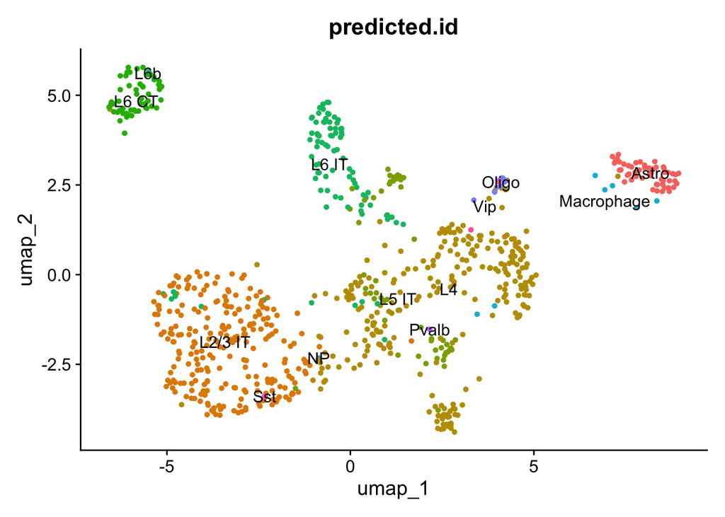

```r
Seurat::DimPlot(seurat_obj, label = TRUE, group.by = "predicted.id") + Seurat::NoLegend()
```

```r
seurat_obj
```

```
#> An object of class Seurat
#> 157203 features across 779 samples within 1 assay
#> Active assay: ATAC (157203 features, 157203 variable features)
#>  2 layers present: counts, data
#>  2 dimensional reductions calculated: lsi, umap
```

# Compute gene activity scores

Since it’s often difficult to “interpret” chromatin regions (i.e., peaks), it’s sometimes convenient to “convert” the scATAC-seq data to be aligned with the genes. `Signac::GeneActivity()` achieves this, where essentially, it looks at the raw `.tsv.gz` file, and then checks for each gene’s TSS, how many cuts happen around that TSS. This essentially results in a matrix that has “genes” as features (instead of “peaks”). See more information in [https://stuartlab.org/signac/reference/geneactivity](https://urldefense.com/v3/__https://stuartlab.org/signac/reference/geneactivity__;!!K-Hz7m0Vt54!l8z1cgLimWUehjP-UQXj91E35KMe10j2zUI4OsZMQE77jhZVMfT9o31RJUgPZ5_ownyYz442rsCy$). Be wary of the default: By default (currently, in Signac version 1.14.0), `extend.upstream = 2000` and `extend.downstream = 0`, which means the cuts are defined as up to 2000 base pairs upstream of the TSS (on the 5’ to 3’ side, i.e., “before” the TSS), and not looking at any cuts after the TSS (downstream). See Figure 5 in https://academic.oup.com/bib/article/25/5/bbae382/7745032 to see that these numbers could be wildly different from method to method.

```r
# compute gene activities
# This takes a couple minutes
gene_activities <- Signac::GeneActivity(seurat_obj)

# add the gene activity matrix to the Seurat object as a new assay
seurat_obj[['RNA']] <- Seurat::CreateAssayObject(counts = gene_activities)

seurat_obj <- Seurat::NormalizeData(
  object = seurat_obj,
  assay = 'RNA'
)
```

[output not shown]

```r
Seurat::DefaultAssay(seurat_obj) <- "RNA"
seurat_obj
```

```
#> An object of class Seurat
#> 179011 features across 779 samples within 2 assays
#> Active assay: RNA (21808 features, 0 variable features)
#>  2 layers present: counts, data
#>  1 other assay present: ATAC
#>  2 dimensional reductions calculated: lsi, umap
```

We can show the underlying count matrix that we’ve constructed. We can see that each row (feature) is now a gene. Of course, this isn’t really a scRNA-seq data (since this is a “conversion” of scATAC-seq into gene counts). Had this been a 10x multiome dataset, we could compare the GeneActivity scores to the observed scRNA-seq counts gene-by-gene to detect which genes are “primed” (or “become accessible”) prior to transcription in which cell types.

```r
count_mat <- SeuratObject::LayerData(seurat_obj,
                                     layer = "counts",
                                     assay = "RNA")
count_mat[1:5,1:5]
```

```
#> 5 x 5 sparse Matrix of class "dgCMatrix"
#>               AAACGAATCCTGGGAC-1 AAACTCGAGAAAGCAG-1 AAACTCGTCCAACGCG-1
#> Hnf4g                          .                  .                  .
#> Zfhx4                          .                  4                  1
#> Pex2                           1                  2                  1
#> UBC                            .                  .                  .
#> 1700008P02Rik                  .                  .                  .
#>               AAACTCGTCCATCATT-1 AAACTCGTCTGGGCGT-1
#> Hnf4g                          .                  1
#> Zfhx4                          2                  3
#> Pex2                           1                  1
#> UBC                            .                  .
#> 1700008P02Rik                  .                  .
```

# Making coverage plots

Since our data is scATAC-seq, we can plot the coverage track. This is a plot that looks like a mountain range, where for each stratification (typically, each cell type or cell cluster), we see across all the cells in that stratification, the average number of cuts that happened at that base pair region. See [https://stuartlab.org/signac/reference/coverageplot](https://urldefense.com/v3/__https://stuartlab.org/signac/reference/coverageplot__;!!K-Hz7m0Vt54!l8z1cgLimWUehjP-UQXj91E35KMe10j2zUI4OsZMQE77jhZVMfT9o31RJUgPZ5_ownyYz4xM-k2R$) for more information. If you dig into the code for this function, you’ll see that the coverage track is a “double average” – first, for each cell, it averages the presence/absence of a cut at any particular base pair with its neighboring base pairs. Then, it averages this averaged cut count across all the cells in that stratification.

```r
Seurat::Idents(seurat_obj) <- "predicted.id"
# show cell types with at least 50 cells
idents_plot <- names(which(table(Seurat::Idents(seurat_obj)) > 50))

idents_plot
```

```
#> [1] "Astro"   "L2/3 IT" "L4"      "L5 IT"   "L6 CT"   "L6 IT"
```

```r
Seurat::DefaultAssay(seurat_obj) <- "ATAC"
```

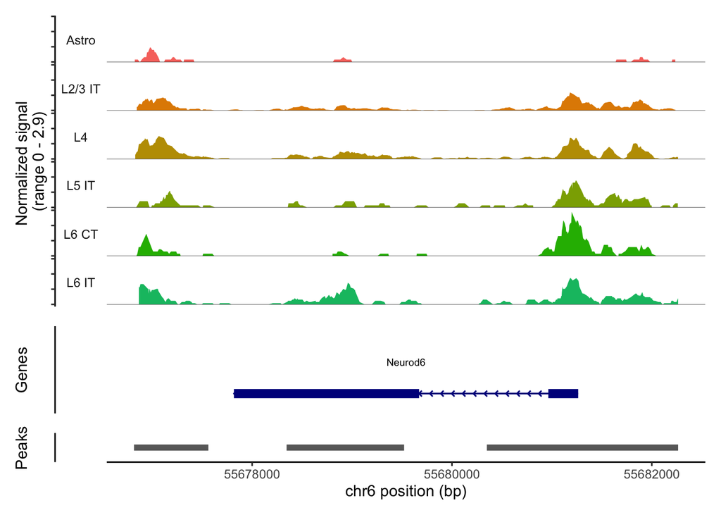

```r
Signac::CoveragePlot(
  object = seurat_obj,
  region = c("Neurod6"),
  idents = idents_plot,
  extend.upstream = 1000,
  extend.downstream = 1000,
  ncol = 1
)
```